# RC2

Haohong Shang

2023-05-22

**This is adapted from UM’s lab material. For the usage of lm() function, you may refer to the RC1_2.Rmd file under folder RC1.**

## Categorical predictors

### 2-level categorical predictors

We first consider a binary categorical predictor into simple linear regression.

- A typical appearance for such predictor is the answer from ‘Yes’/‘No’ questionnaire.
- For example, let ‘$x$’ be a binary predictor indicating whether you are from Michigan or not.
- The convention is to treat them as 0/1 indicators. That is, we label ‘yes’ as $1$, while ‘no’ as $0$. (Sometimes the other way around..)

Consider the following model
$$y_i = \beta_0 + \beta_1 x_i + \varepsilon_i,$$
where $x_i$ only takes 0 or 1, indicating the binary predictor. This means
$$y_i =
\begin{cases}
\beta_0 + \beta_1 + \varepsilon_i,& \text{if } x_i = 1\\
\beta_0 + \varepsilon_i,& \text{if } x_i = 0
\end{cases}$$

- What’s the interpretation of $\beta_0$ and $\beta_1$?
- $\beta_1$: The average difference in $Y$ between the two categories.
- $\beta_0$: The average of $Y$ for the baseline group (Here baseline is x_i = 0).

Following the same strategy in lecture, we can derive the expression for the estimator $\widehat{\beta}_0$ and $\widehat{\beta}_1$. Let $\bar{Y}_1$ be the sample average of $y_i$ among those $x_i = 1$, while $\bar{Y}_0$ be the sample average of $y_i$ among $x_i = 0$.

$$\begin{eqnarray*}
\widehat{\beta}_0 &=& \bar{Y}_0\\
\widehat{\beta}_1 &=& \bar{Y}_1 - \bar{Y}_0
\end{eqnarray*}$$

- Does those expressions seems intuitive?
- What would happen if we label `Yes` as 2 and `No` as 0?

To see a real-world application, we turn to the `Credit` dataset from the `ISLR` package. The data set records information on credit card clients. We first try to model `Balance` using a binary predictor `Student`.

- `Balance` records the average credit balance for a client
- `Student` is binary, representing whether the user is a student or not.
- A summary of the variable `Student` shows it’s indeed categorical.

```r
library(ISLR)
data(Credit)
summary(Credit$Student)
```

```
##  No Yes
## 360  40
```

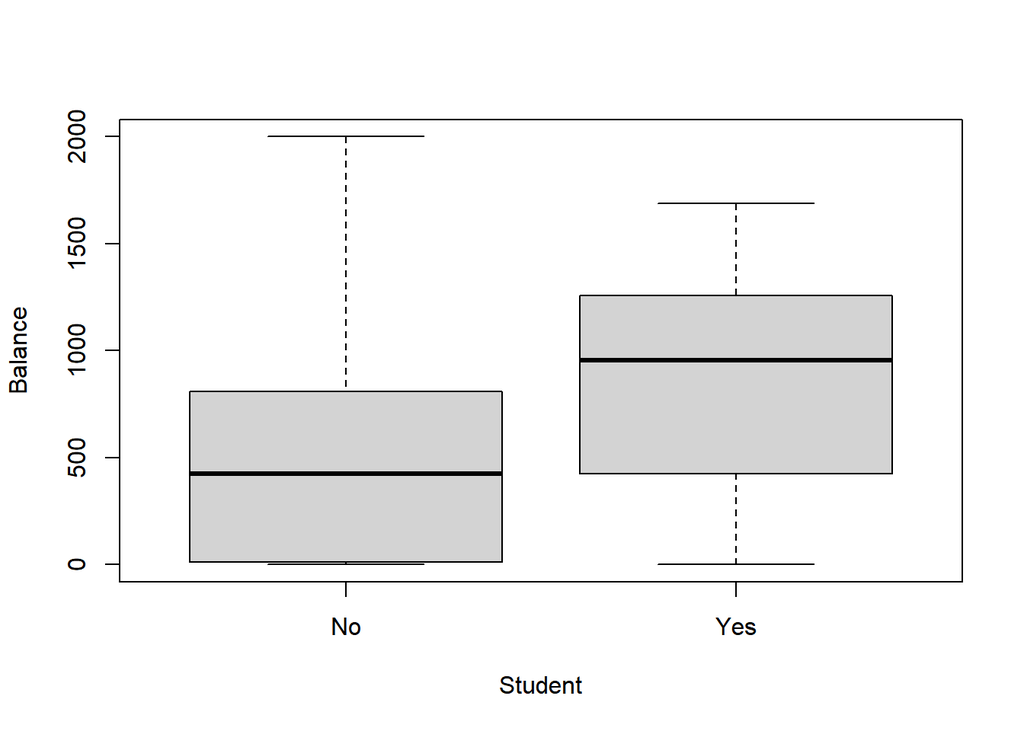

```r
plot(Balance~Student, data = Credit)
```

Then we can fit a simple linear regression model of `Balance~Student`.

```r
fit1 = lm(Balance~Student, data = Credit)
summary(fit1)
```

```
##
## Call:
## lm(formula = Balance ~ Student, data = Credit)
##
## Residuals:
##     Min      1Q  Median      3Q     Max
## -876.82 -458.82  -40.87  341.88 1518.63
##
## Coefficients:
##             Estimate Std. Error t value Pr(>|t|)
## (Intercept)   480.37      23.43   20.50  < 2e-16 ***
## StudentYes    396.46      74.10    5.35 1.49e-07 ***
## ---
## Signif. codes:  0 '***' 0.001 '**' 0.01 '*' 0.05 '.' 0.1 ' ' 1
##
## Residual standard error: 444.6 on 398 degrees of freedom
## Multiple R-squared:  0.06709,    Adjusted R-squared:  0.06475
## F-statistic: 28.62 on 1 and 398 DF,  p-value: 1.488e-07
```

- Is the coefficient for ‘Student’ significant?
- While `R` implement the regression above, how do we know if ‘Yes’ = 1 or ‘No’ = 1?

We can easily verify that the estimated values have the desired interpreration.

```r
beta0.hat = mean(Credit$Balance[Credit$Student == 'No'])
beta1.hat = mean(Credit$Balance[Credit$Student == 'Yes']) - mean(Credit$Balance[Credit$Student == 'No'])
c(beta0.hat,beta1.hat)
```

```
## [1] 480.3694 396.4556
```

```r
coef(fit1)
```

```
## (Intercept)  StudentYes
##    480.3694    396.4556
```

If we would like to put ‘Yes’ as our baseline instead, the function `relevel` comes handy.

```r
fit2 = lm(Balance~relevel(Student, ref = 'Yes'), data = Credit)
summary(fit2)
```

```
##
## Call:
## lm(formula = Balance ~ relevel(Student, ref = "Yes"), data = Credit)
##
## Residuals:
##     Min      1Q  Median      3Q     Max
## -876.83 -458.83  -40.87  341.88 1518.63
##
## Coefficients:
##                                 Estimate Std. Error t value Pr(>|t|)
## (Intercept)                        876.8       70.3   12.47  < 2e-16 ***
## relevel(Student, ref = "Yes")No   -396.5       74.1   -5.35 1.49e-07 ***
## ---
## Signif. codes:  0 '***' 0.001 '**' 0.01 '*' 0.05 '.' 0.1 ' ' 1
##
## Residual standard error: 444.6 on 398 degrees of freedom
## Multiple R-squared:  0.06709,    Adjusted R-squared:  0.06475
## F-statistic: 28.62 on 1 and 398 DF,  p-value: 1.488e-07
```

Another way of doing this is adjusting the order of the levels first.

```r
levels(Credit$Student)
```

```
## [1] "No"  "Yes"
```

```r
Credit$MyStudent =  factor(Credit$Student, levels = c("Yes", "No"))
levels(Credit$MyStudent)
```

```
## [1] "Yes" "No"
```

```r
fit2.1 = lm(Balance~MyStudent , data = Credit)
summary(fit2.1)
```

```
##
## Call:
## lm(formula = Balance ~ MyStudent, data = Credit)
##
## Residuals:
##     Min      1Q  Median      3Q     Max
## -876.83 -458.83  -40.87  341.88 1518.63
##
## Coefficients:
##             Estimate Std. Error t value Pr(>|t|)
## (Intercept)    876.8       70.3   12.47  < 2e-16 ***
## MyStudentNo   -396.5       74.1   -5.35 1.49e-07 ***
## ---
## Signif. codes:  0 '***' 0.001 '**' 0.01 '*' 0.05 '.' 0.1 ' ' 1
##
## Residual standard error: 444.6 on 398 degrees of freedom
## Multiple R-squared:  0.06709,    Adjusted R-squared:  0.06475
## F-statistic: 28.62 on 1 and 398 DF,  p-value: 1.488e-07
```

- The `level` function reveals all the possible levels of a categorical variable .
- The `factor` function creates a categorical variable in `R` with the specified level names .

### Multiple regression

Now let’s try to include some other continuous variable in the model.

```r
fit3 = lm(Balance~Student + Income + Rating + Age, data = Credit)
summary(fit3)
```

```
##
## Call:
## lm(formula = Balance ~ Student + Income + Rating + Age, data = Credit)
##
## Residuals:
##      Min       1Q   Median       3Q      Max
## -217.606  -79.887   -8.163   62.680  292.009
##
## Coefficients:
##               Estimate Std. Error t value Pr(>|t|)
## (Intercept) -547.30470   21.46064 -25.503   <2e-16 ***
## StudentYes   417.50564   17.17164  24.314   <2e-16 ***
## Income        -7.79773    0.24218 -32.198   <2e-16 ***
## Rating         3.98073    0.05458  72.927   <2e-16 ***
## Age           -0.62418    0.30407  -2.053   0.0408 *
## ---
## Signif. codes:  0 '***' 0.001 '**' 0.01 '*' 0.05 '.' 0.1 ' ' 1
##
## Residual standard error: 102.9 on 395 degrees of freedom
## Multiple R-squared:  0.9504, Adjusted R-squared:  0.9499
## F-statistic:  1892 on 4 and 395 DF,  p-value: < 2.2e-16
```

- How would you interpret the coefficient for `Student` now?

## Multi-level categorical predictor

Now let’s consider the case with more than two levels. First we take a look at the variable `Ethnicity`.

```r
summary(Credit$Ethnicity)
```

```
## African American            Asian        Caucasian
##               99              102              199
```

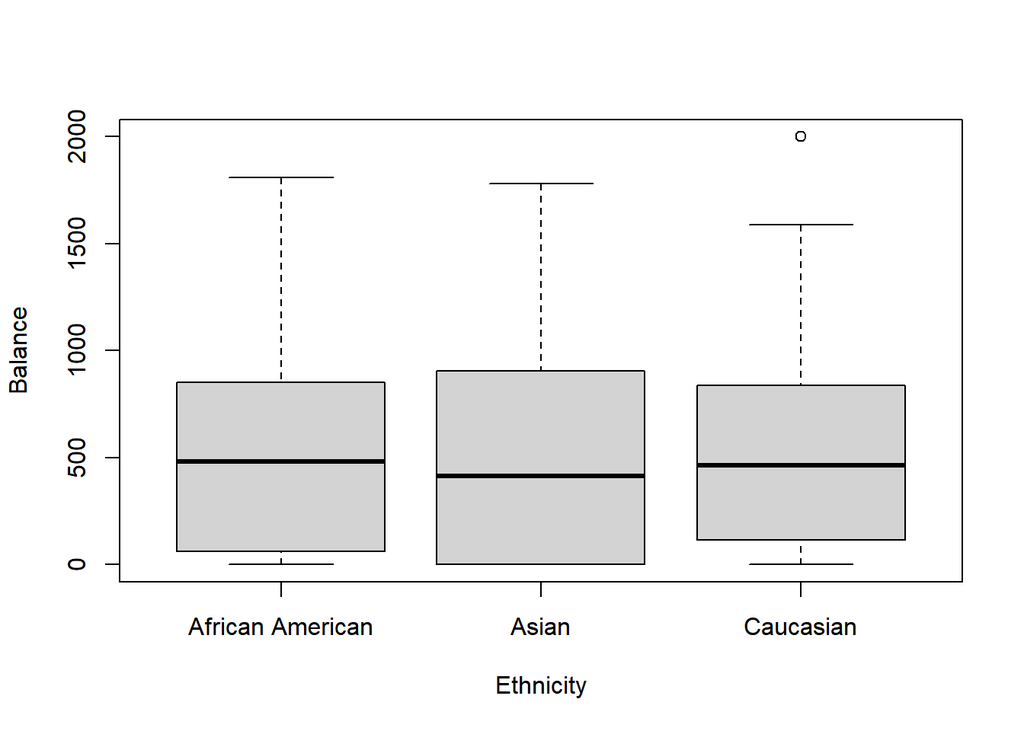

```r
plot(Balance ~ Ethnicity , data = Credit)
```

- There are three levels.
- There does not seem to be a significant relationship between the balance and ethnicity.
- Would indexing `Ethnicity` as a integer of 0/1/2 work like the binary case?

To incorporate this, we introduce a set of ‘dummy’ variables. Suppose $x$ has $d$ distinct levels denoted as $f_1,\ldots,f_d$ (They are not numeric!). Let $z_1,\ldots,z_{d-1}$ be $d-1$ binary (dummy) variables that are:
$$z_k =
\begin{cases}
1,& \text{if }x = f_k\\
0,& \text{Otherwise}
\end{cases}$$
Then we fit the regression as if we use those $d-1$ dummy variables $z_1,\ldots,z_{d-1}$ instead of the original categorical variable $x$ in the linear regression.

Now let’s see how that works in practice.

```r
fit4 = lm(Balance~ Ethnicity, data = Credit)
summary(fit4)
```

```
##
## Call:
## lm(formula = Balance ~ Ethnicity, data = Credit)
##
## Residuals:
##     Min      1Q  Median      3Q     Max
## -531.00 -457.08  -63.25  339.25 1480.50
##
## Coefficients:
##                    Estimate Std. Error t value Pr(>|t|)
## (Intercept)          531.00      46.32  11.464   <2e-16 ***
## EthnicityAsian       -18.69      65.02  -0.287    0.774
## EthnicityCaucasian   -12.50      56.68  -0.221    0.826
## ---
## Signif. codes:  0 '***' 0.001 '**' 0.01 '*' 0.05 '.' 0.1 ' ' 1
##
## Residual standard error: 460.9 on 397 degrees of freedom
## Multiple R-squared:  0.0002188,  Adjusted R-squared:  -0.004818
## F-statistic: 0.04344 on 2 and 397 DF,  p-value: 0.9575
```

- Which level is the baseline?
- Now, the coefficients represents the average difference with the level.
- Does it appear to be a significant difference between each ethnicity?

Alternatively, we can create our own 0/1 valued dummy variables.

```r
Credit$AfAmer <- as.numeric(Credit$Ethnicity == 'African American')
Credit$Asian <- as.numeric(Credit$Ethnicity == 'Asian')
Credit$Cauc <- as.numeric(Credit$Ethnicity == 'Caucasian')
table(Credit$AfAmer)
```

```
##
##   0   1
## 301  99
```

- The `==` operator in `R` compares the left and right hand side, returning a logical value TRUE/FALSE.
- In our case, it returns a vector of the same length as `Credit$Ethnicity`.
- The `as.numeric` convert those logical variable to 1/0.

Suppose we use `African American` as the baseline level. Fitting a linear regression using our dummies gives the same result.

```r
fit5 = lm(Balance~ Asian + Cauc, data = Credit)
coef(fit5)
```

```
## (Intercept)       Asian        Cauc
##   531.00000   -18.68627   -12.50251
```

```r
coef(fit4)
```

```
##        (Intercept)     EthnicityAsian EthnicityCaucasian
##          531.00000          -18.68627          -12.50251
```

Of course we can involve more predictors in the model.

```r
fit6 = lm(Balance~ Ethnicity + Student + Income + Rating + Age, data = Credit)
summary(fit6)
```

```
##
## Call:
## lm(formula = Balance ~ Ethnicity + Student + Income + Rating +
##     Age, data = Credit)
##
## Residuals:
##     Min      1Q  Median      3Q     Max
## -218.14  -82.41  -11.24   64.17  291.85
##
## Coefficients:
##                      Estimate Std. Error t value Pr(>|t|)
## (Intercept)        -558.91663   23.82767 -23.457   <2e-16 ***
## EthnicityAsian       19.11395   14.58032   1.311   0.1906
## EthnicityCaucasian    9.24769   12.68082   0.729   0.4663
## StudentYes          416.82254   17.20402  24.228   <2e-16 ***
## Income               -7.80138    0.24238 -32.186   <2e-16 ***
## Rating                3.98304    0.05465  72.889   <2e-16 ***
## Age                  -0.59631    0.30492  -1.956   0.0512 .
## ---
## Signif. codes:  0 '***' 0.001 '**' 0.01 '*' 0.05 '.' 0.1 ' ' 1
##
## Residual standard error: 102.9 on 393 degrees of freedom
## Multiple R-squared:  0.9506, Adjusted R-squared:  0.9499
## F-statistic:  1261 on 6 and 393 DF,  p-value: < 2.2e-16
```

- Note the interpretation of the ‘intercept’ terms now involves the baseline of `Ethnicity` and `Student`.

## Interactions

We will briefly introduce the interaction effect. An interaction term between two variables $x_1$ and $x_2$ means the product term $x_1\cdot x_2$. For example, a linear regression with predictor $x_1$, $x_2$ and their interaction is:
$$y = \beta_0 + x_1\beta_{1} + x_2\beta_2 + x_1x_2\beta_3 + \varepsilon$$

- This is particularly interesting when $x_1$ is categorical (binary).
- Intuitively, the marginal effect of $x_2$ depend on the level of $x_1$.

Let’s look at the interaction between `Student` and `Rating`.

```r
fit7 = lm(Balance ~ Income + Student + Rating + Student:Rating , data = Credit)
summary(fit7)
```

```
##
## Call:
## lm(formula = Balance ~ Income + Student + Rating + Student:Rating,
##     data = Credit)
##
## Residuals:
##      Min       1Q   Median       3Q      Max
## -217.930  -78.225   -5.887   66.799  284.319
##
## Coefficients:
##                     Estimate Std. Error t value Pr(>|t|)
## (Intercept)       -568.38426   14.07027 -40.396  < 2e-16 ***
## Income              -7.91290    0.23684 -33.410  < 2e-16 ***
## StudentYes         271.73432   43.97212   6.180  1.6e-09 ***
## Rating               3.95653    0.05456  72.518  < 2e-16 ***
## StudentYes:Rating    0.41548    0.11463   3.624 0.000327 ***
## ---
## Signif. codes:  0 '***' 0.001 '**' 0.01 '*' 0.05 '.' 0.1 ' ' 1
##
## Residual standard error: 101.8 on 395 degrees of freedom
## Multiple R-squared:  0.9515, Adjusted R-squared:  0.951
## F-statistic:  1937 on 4 and 395 DF,  p-value: < 2.2e-16
```